# EDA_QJ

QJ

11/30/2021

```r
library(tidyverse)
load("bike_join.RData")

# NYC Covid Data: https://github.com/nychealth/coronavirus-data/tree/master/trends
coviddata <- read_csv("COVIDcasedata.csv")
# NYC Weather Data: New York, NY 10023 https://www.ncdc.noaa.gov/cdo-web/datasets/GHCND/locations/ZIP:10023/detail
weatherdata <- read_csv("NYCWeather.csv")
```

## Data Clean-up

```r
#removing observations with more than 2 hours
bike_join_filter = bike_join[!bike_join$trip_min > 120,]

library(lubridate)
#adding COVID information to the data

coviddata$Date =  mdy(coviddata$date_of_interest)
coviddata_prejoin = coviddata %>% select(Date, CASE_COUNT_7DAY_AVG)

bikedata_weather_covid = bike_join_filter %>% left_join(coviddata_prejoin, by = c("trip_date" = "Date"))
```

Before starting our exploratory data analysis, we first subset the dataset to remove trips that took more than 2 hours. This is because it is probably unrealistic to expect realistic results for extremely large trip durations (sometimes durations amounting to multiple days can be attributed to staff returning abandoned bicycles). Next we will join in weather data (previously done before reading in the data) as well as COVID-19 data, which may provide us with some additional insights into trip duration.

```r
#sampling data stratified by trip_date
set.seed(260)
bikedata_weather_covid_sample = bikedata_weather_covid %>% group_by(trip_date) %>% sample_frac(0.01) %>% ungroup(trip_date)
```

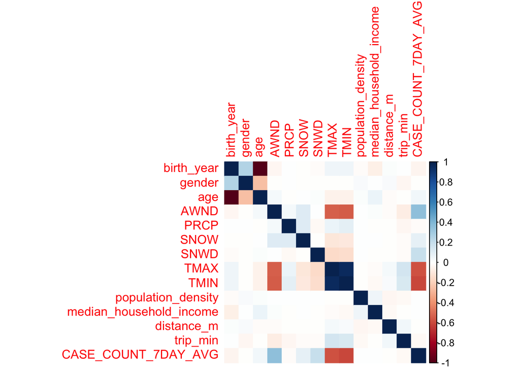

```r
#correlation plot
library(corrplot)
#names(bikedata_weather_covid_sample)

bikedata_weather_covid_sample_num = select_if(bikedata_weather_covid_sample, is.numeric) %>% select(-start_station_id, -end_station_id, -start_station_latitude, -start_station_longitude, -end_station_longitude, -end_station_latitude, -bike_id, -trip_duration)

bikedata_weather_covid_sample_num %>% cor(use="pairwise.complete.obs") %>% corrplot(method = 'color')
```

```r
sort(abs(cor(bikedata_weather_covid_sample_num,use="pairwise.complete.obs")[13,]), decreasing = TRUE)
```

```
##                trip_min                    TMAX                    TMIN
##             1.000000000             0.157589970             0.139471847
##                    AWND              distance_m                  gender
##             0.077712782             0.040559144             0.039946715
##                    PRCP      population_density     CASE_COUNT_7DAY_AVG
##             0.033258303             0.026188478             0.020795921
##                    SNWD                    SNOW                     age
##             0.018651635             0.017670720             0.006087475
##              birth_year median_household_income
##             0.006087475             0.002230868
```

```r
summary(bikedata_weather_covid$trip_duration/60)
```

```
##    Min. 1st Qu.  Median    Mean 3rd Qu.    Max.
##   1.017   7.033  12.900  17.054  23.133 120.000
```

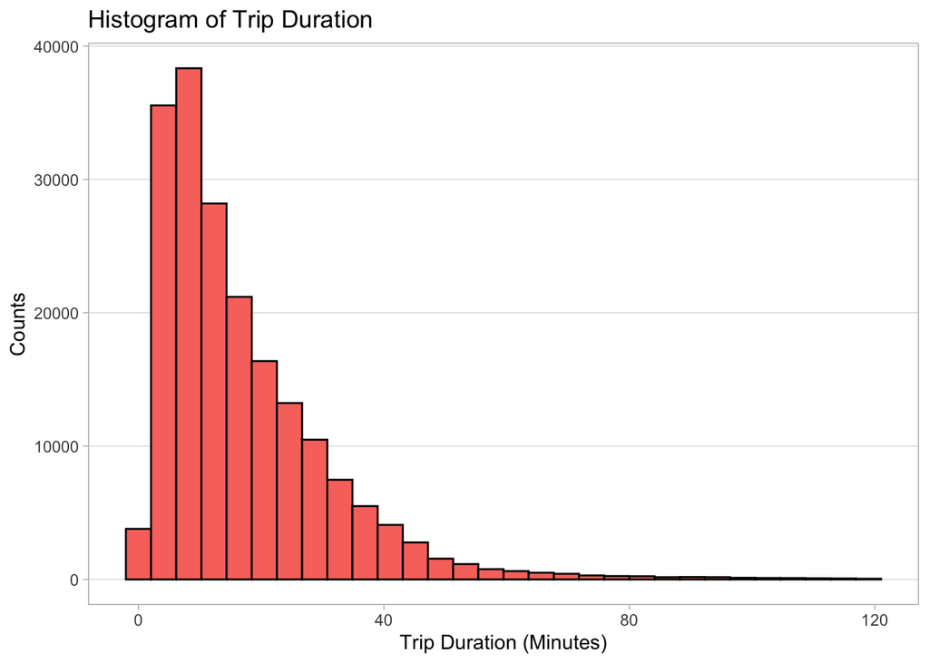

```r
bikedata_weather_covid_sample %>%
  ggplot(aes(trip_duration/60, fill = "#379DDA")) +
  geom_histogram(color = 'black') +
  #xlim(0, 170) +
  ylab('Counts') +
  xlab('Trip Duration (Minutes)') +
  ggtitle('Histogram of Trip Duration') +
  theme_light() +
  theme(panel.grid.minor = element_blank(),
        panel.grid.major.x = element_blank()) +
  theme(legend.position = "none")
```

As expected, trip duration appears to be heavily right skewed, with most of the observations appearing to take 15 minutes or less.

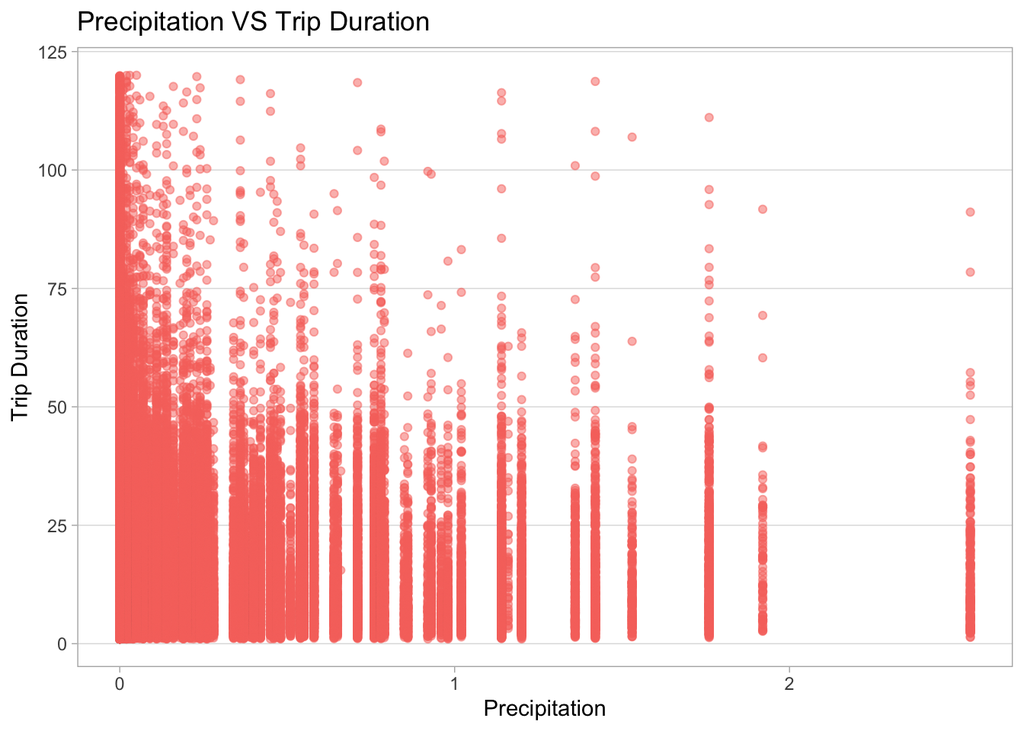

```r
bikedata_weather_covid_sample %>%
  ggplot(aes(x=PRCP, y=trip_duration/60, color = "#379DDA")) +
  geom_point(alpha = 0.5) +
  ylab('Trip Duration') +
  xlab('Precipitation') +
  #ylim(0,10000) +
  ggtitle('Precipitation VS Trip Duration') +
  theme_light() +
  theme(panel.grid.minor = element_blank(),
        panel.grid.major.x = element_blank()) +
  theme(legend.position = "none")
```

The scatterplot of trip duration against precipitation appears to show a generally decreasing pattern of trip duration as precipitation increases. However, we have far more data points for lower values of precipitation, which may partially explain the larger range of values of trip duration for lower precipitation.

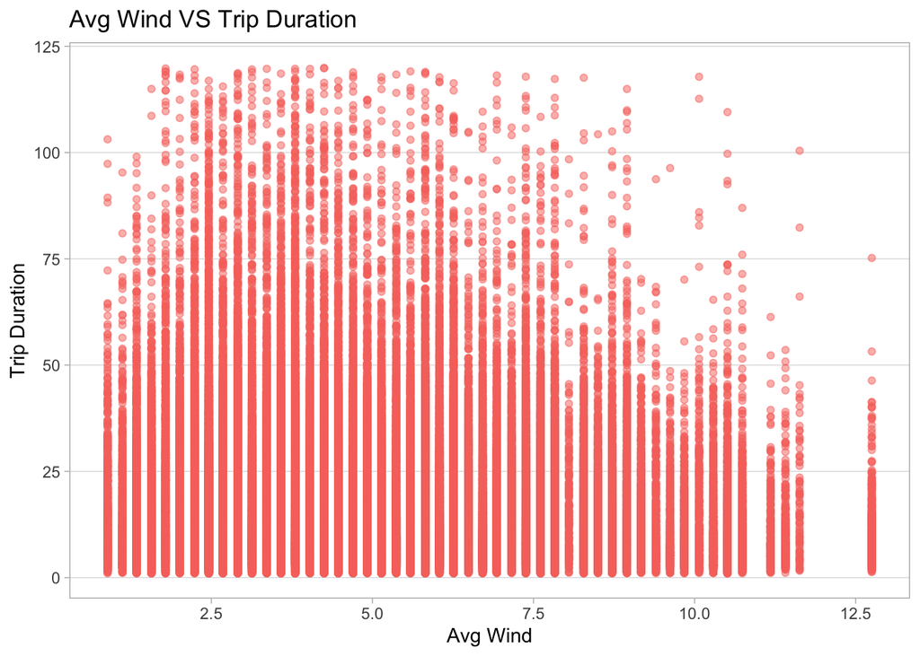

```r
bikedata_weather_covid_sample %>%
  ggplot(aes(x=AWND, y=trip_duration/60, color = "#379DDA")) +
  geom_point(alpha = 0.5) +
  ylab('Trip Duration') +
  xlab('Avg Wind') +
  ggtitle('Avg Wind VS Trip Duration') +
  theme_light() +
  theme(panel.grid.minor = element_blank(),
        panel.grid.major.x = element_blank()) +
  theme(legend.position = "none")
```

The scatterplot of trip duration against average wind appears to be generally uncorrelated.

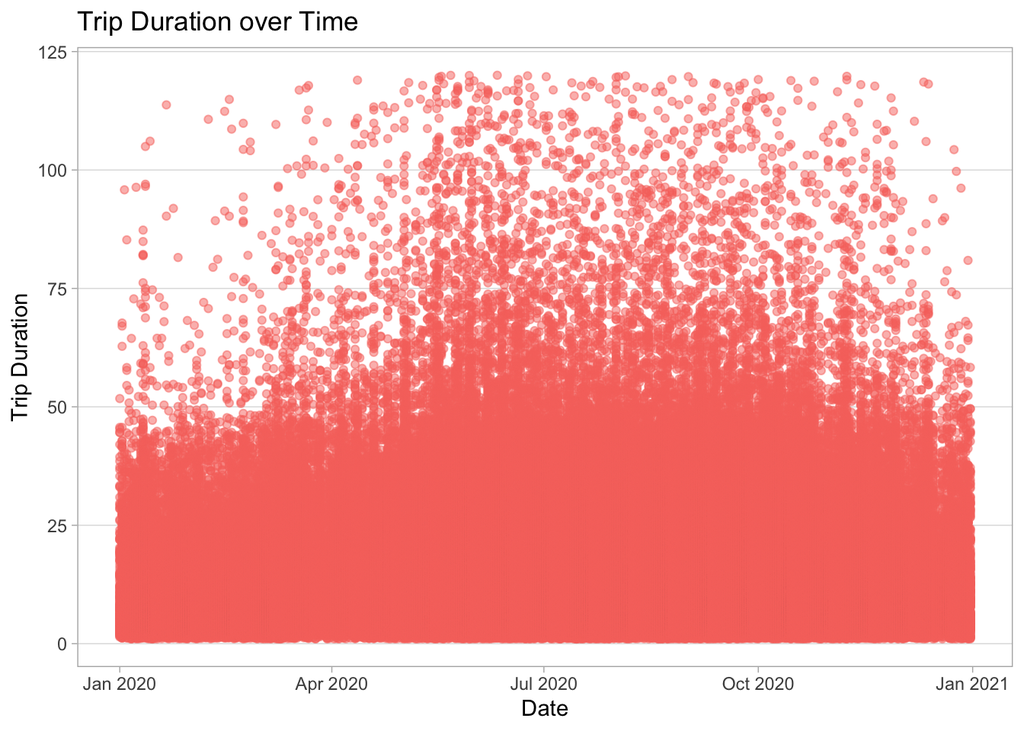

```r
bikedata_weather_covid_sample %>%
  ggplot(aes(x=trip_date, y=trip_duration/60, color = "#379DDA")) +
  geom_point(alpha = 0.5) +
  ylab('Trip Duration') +
  xlab('Date') +
  ggtitle('Trip Duration over Time') +
  theme_light() +
  theme(panel.grid.minor = element_blank(),
        panel.grid.major.x = element_blank()) +
  theme(legend.position = "none")
```